# Econ302 - R Assignment - 1

Mert Yazal

10/24/2019

# Task 1

Task 1 requires OLS Estimation, DW and Breusch-Pagan Test.

### OLS Estimation

Let’s estimate our regression model $Y_t = \beta_0 + \beta_1{X_t} + \beta_2{Z_t} + u_t$, and plot what the series are revealing:

#### OLS

```
##
## Call:
## lm(formula = Y ~ X + Z, data = data)
##
## Residuals:
##     Min      1Q  Median      3Q     Max
## -182.57  -19.13   22.15   35.28   50.70
##
## Coefficients:
##             Estimate Std. Error t value Pr(>|t|)
## (Intercept)   75.404     31.472   2.396   0.0292 *
## X              2.896      1.328   2.180   0.0445 *
## Z             67.125     30.818   2.178   0.0447 *
## ---
## Signif. codes:  0 '***' 0.001 '**' 0.01 '*' 0.05 '.' 0.1 ' ' 1
##
## Residual standard error: 59.7 on 16 degrees of freedom
## Multiple R-squared:  0.8094, Adjusted R-squared:  0.7856
## F-statistic: 33.97 on 2 and 16 DF,  p-value: 1.742e-06
```

We obtain: $\widehat{Y_{t}} = \widehat{\beta_0} + \widehat{\beta_1}X_{t} + \widehat{\beta_2}Z_{t}$

$\widehat{Y_{t}} = 75.404478 + 2.8961391 X_{t} + 67.1247119 Z_{t}$

#### Variables all together

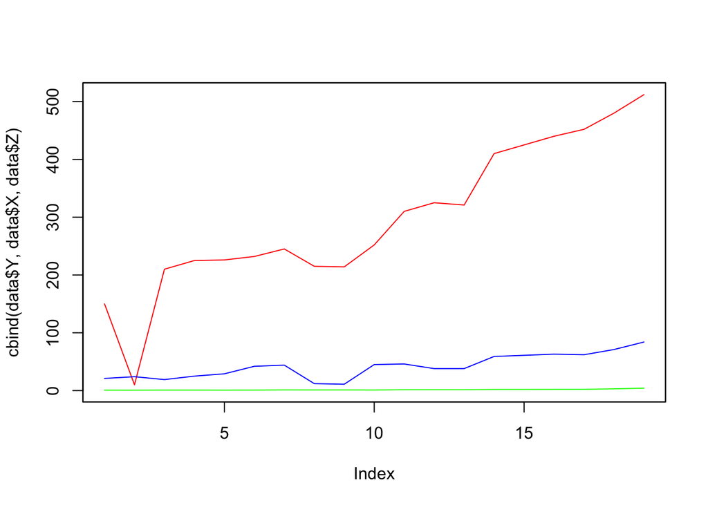

Variables Y, X and Z respectively colors red, blue and green.

#### Y

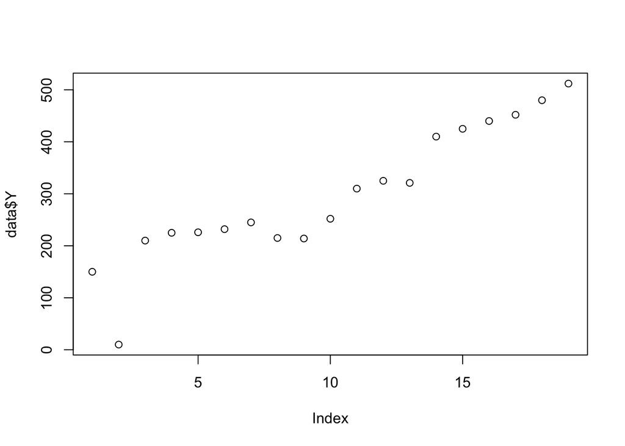

Therefore, we observe that there is an increasing trend in each variables. They do not well behave.

We obtain: $\widehat{Y_{t}} = \widehat{\beta_0} + \widehat{\beta_1}X_{t} + \widehat{\beta_2}Z_{t}$

$\widehat{Y_{t}} = 75.404478 + 2.8961391 X_{t} + 67.1247119 Z_{t}$

#### X

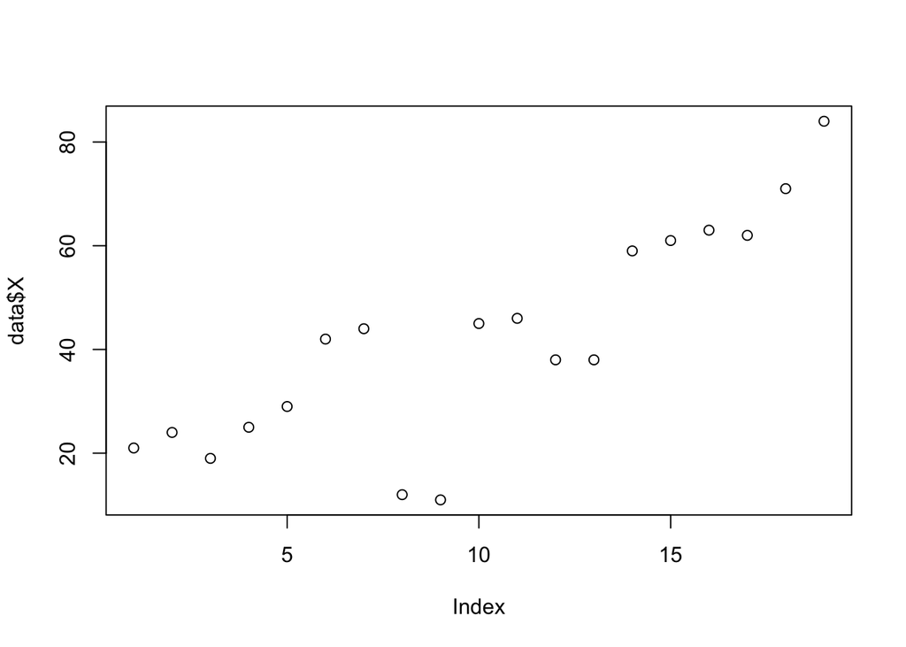

Therefore, we observe that there is an increasing trend in each variables. They do not well behave.

We obtain: $\widehat{Y_{t}} = \widehat{\beta_0} + \widehat{\beta_1}X_{t} + \widehat{\beta_2}Z_{t}$

$\widehat{Y_{t}} = 75.404478 + 2.8961391 X_{t} + 67.1247119 Z_{t}$

#### Z

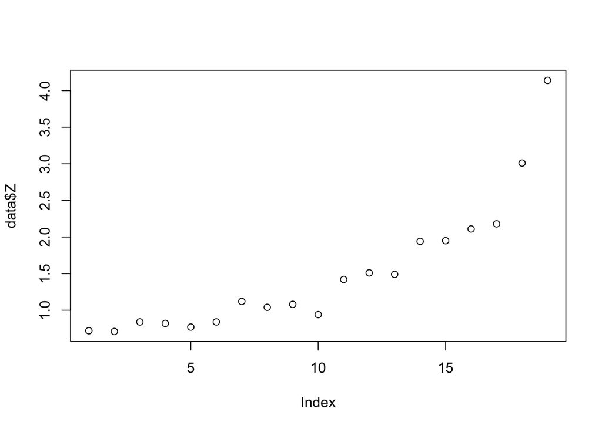

Therefore, we observe that there is an increasing trend in each variables. They do not well behave.

We obtain: $\widehat{Y_{t}} = \widehat{\beta_0} + \widehat{\beta_1}X_{t} + \widehat{\beta_2}Z_{t}$

$\widehat{Y_{t}} = 75.404478 + 2.8961391 X_{t} + 67.1247119 Z_{t}$

#### extra: Residuals for $Y_t = \beta_0 + \beta_1{X_t} + u_t$

Residuals

```
##           1           2           3           4           5           6
##  -35.634588 -191.788584   35.134743   17.826751   -2.711911  -66.712561
##           7           8           9          10          11          12
##  -64.481892   77.827401   82.212067  -62.866557  -10.251223   47.826101
##          13          14          15          16          17          18
##   43.826101   19.748127   23.978796   28.209465   45.594131   25.132142
##          19
##  -12.868508
```

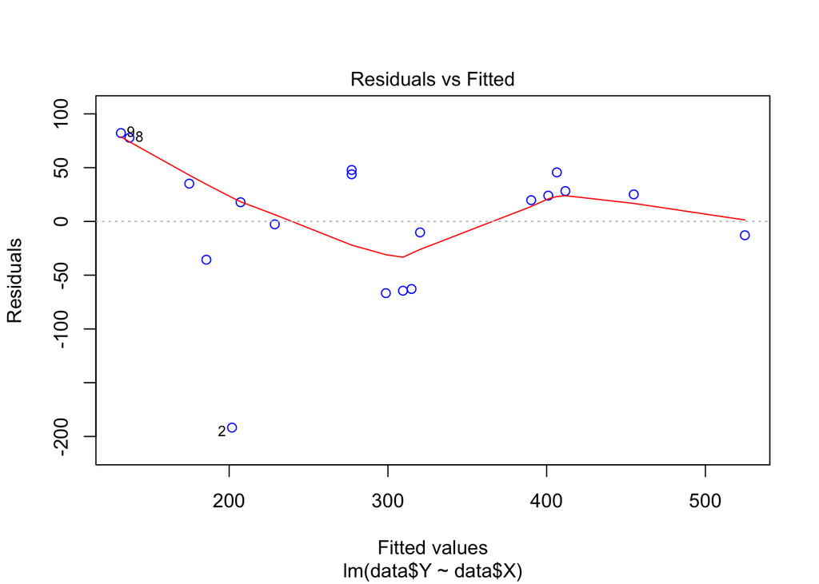

[figure not shown]

$\widehat{Y_{t}} = 72.5566139 + 5.3846654 X_{t}$

$\widehat{Y_{t}} = \widehat{\beta_0} + \widehat{\beta_1}X_{t} + \widehat{\beta_2}Z_{t}$

#### extra: Residuals for $Y_t = \beta_0 + \beta_1{Z_t} + u_t$

Residuals

```
##           1           2           3           4           5           6
##  -49.279930 -188.030645   -4.271352   13.227218   20.473644   17.728648
##           7           8           9          10          11          12
##   -4.251337  -24.257056  -30.254196   25.235796   23.270108   27.026542
##          13          14          15          16          17          18
##   25.525112   58.307279   72.057994   67.069432   70.324435   -5.366233
##          19
## -114.535457
```

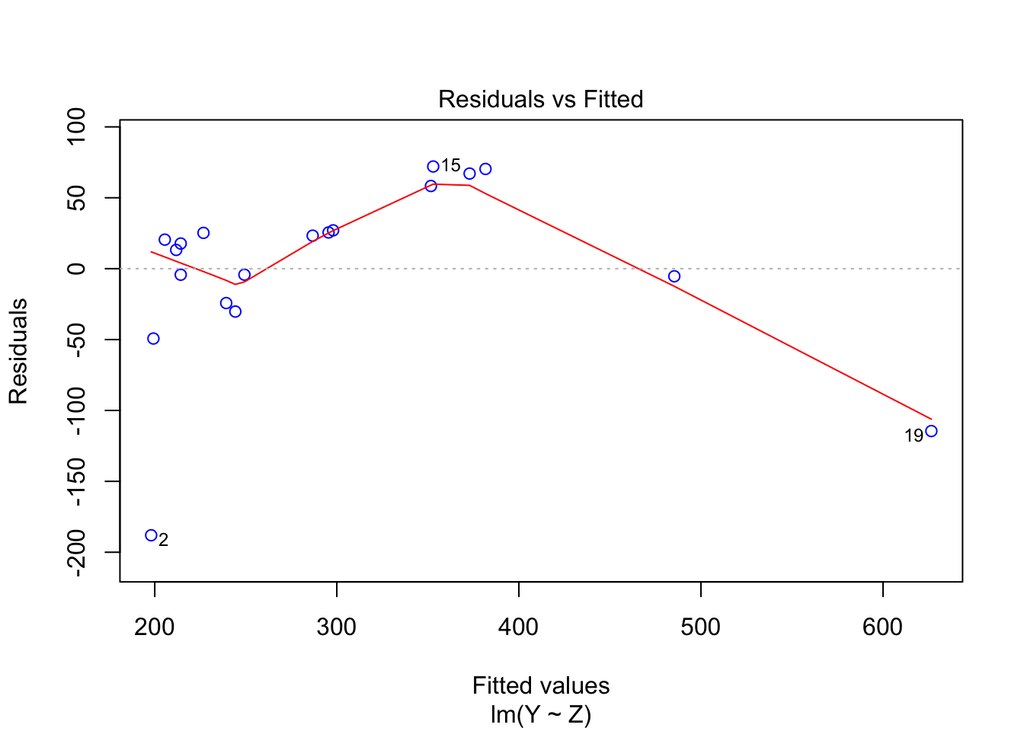

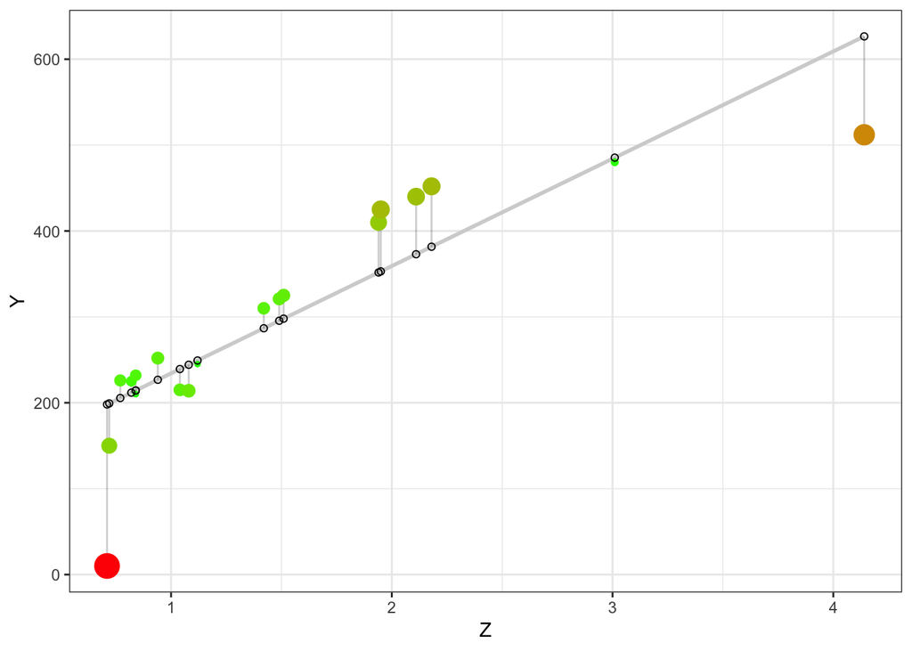

$\widehat{Y_{t}} = 109.3313985 + 124.9285165 Z_{t}$

#### 3D scatter plot

Residuals in 3D

[interactive chart not shown]

### Durbin Watson Test for Autocorrelation

The estimation results of the following specification of the static model is as follows:

```
##  lag Autocorrelation D-W Statistic p-value
##    1        0.187961      1.477713    0.15
##  Alternative hypothesis: rho != 0
```

We observe positive DW value, it may have AC problem since we do not know the intervals of upper and lower d statistics. Prob[DW] = 0.15 > 0.05 do not Rho. NO AC problem.

```
##
##  Durbin-Watson test
##
## data:  model1
## DW = 1.4777, p-value = 0.06946
## alternative hypothesis: true autocorrelation is greater than 0
```

However, in other DW Test, our p value results 0.06.

The estimation results of the following specification of the static model is as follows:

```
##
##  studentized Breusch-Pagan test
##
## data:  model1
## BP = 0.22615, df = 2, p-value = 0.8931
```

Do not RHo, there is no HC at $\alpha$ = 0.05 level of significance.

# Task 2

### OLS Estimation of dynamic model

Task 2 requires the estimation of dynamic model, $Y_t = \alpha_0 + \alpha_1{Y_{t-1}} + \alpha_2{X_{t}} + \alpha_3{Z_{t}} + \alpha_4{X_{t-1}} + \alpha_5{Z_{t-1}} + \epsilon_t$ with ARDL(1,1,1).

```
##
## Call:
## lm(formula = Y ~ X + Z + Ylag + Xlag + Zlag, data = data)
##
## Residuals:
##      Min       1Q   Median       3Q      Max
## -172.370   -6.908    8.162   20.312   64.664
##
## Coefficients:
##             Estimate Std. Error t value Pr(>|t|)
## (Intercept)  38.4490    40.9642   0.939    0.366
## X             1.9980     1.5231   1.312    0.214
## Z            -0.3356    67.4958  -0.005    0.996
## Ylag          0.2075     0.3450   0.601    0.559
## Xlag          0.8961     1.5813   0.567    0.581
## Zlag         64.2615   105.8238   0.607    0.555
##
## Residual standard error: 60.01 on 12 degrees of freedom
##   (1 observation deleted due to missingness)
## Multiple R-squared:  0.8436, Adjusted R-squared:  0.7784
## F-statistic: 12.94 on 5 and 12 DF,  p-value: 0.0001732
```

Therefore, our model becomes $\widehat{Y_{t}} = 38.4489659 + 1.9979573 X_{t} + -0.335551 Z_{t} + 0.2074751 Y_{t-1} + 0.8961434 X_{t-1} + 64.2615012 Z_{t-1}$